# STAT5003Stage2

## 1 Overview of the problem

COVID-19 has had a huge impact on the global airline industry. As the coronavirus pandemic is coming to an end, airline companies need to work hard to revive their business. To help the airline industry, our group did some experiments to find out the most important features that impact passengers’ satisfaction. We utilized a dataset called Airline Passenger Satisfaction[1], which contains an airline passenger satisfaction survey. Since the response variable, “Satisfaction”, is separated into two categories, this problem can be defined as a binary classification problem.

## 2. Dataset description

```r
dftrain <- read.csv("train.csv")
dftest <- read.csv("test.csv")
all <- rbind(dftrain,dftest)

# Impute missing values
lm1 <- lm(Arrival.Delay.in.Minutes ~ Departure.Delay.in.Minutes, data = all)
all$Arrival.Delay.in.Minutes[is.na(all$Arrival.Delay.in.Minutes)] <- predict(lm1, data.frame(Departure.Delay.in.Minutes = all$Departure.Delay.in.Minutes[is.na(all$Arrival.Delay.in.Minutes)]))

# Encoding
all$Class[all$Class == "Eco"] = 0
all$Class[all$Class == "Eco Plus"] = 1
all$Class[all$Class == "Business"] = 2
all$Class = as.numeric(all$Class)

all$Gender[all$Gender == "Male"] = 0
all$Gender[all$Gender == "Female"] = 1
all$Gender = as.numeric(all$Gender)

all$Type.of.Travel[all$Type.of.Travel == "Personal Travel"] = 0
all$Type.of.Travel[all$Type.of.Travel == "Business travel"] = 1
all$Type.of.Travel = as.numeric(all$Type.of.Travel)

all$Customer.Type[all$Customer.Type=="disloyal Customer"] = 0
all$Customer.Type[all$Customer.Type=="Loyal Customer"] = 1
all$Customer.Type = as.numeric(all$Customer.Type)

# Remove outlier
no_outliers_all <- df <- subset(all, all$Departure.Delay.in.Minutes < 1500 & all$Arrival.Delay.in.Minutes < 1500)

# Standardization and factorization
df <- df[,-c(1,2)]
df[,-23] <- scale(df[,-23])
df$satisfaction <- factor(df$satisfaction)

df.tbl <- tibble(rbind(dftrain,dftest))
df.pos <- df.tbl %>% filter(satisfaction=="satisfied")
df.neg <- df.tbl %>% filter(satisfaction=="neutral or dissatisfied")
```

## 3. Initial data analysis and visualization

### 3.1 Missing values and outliers

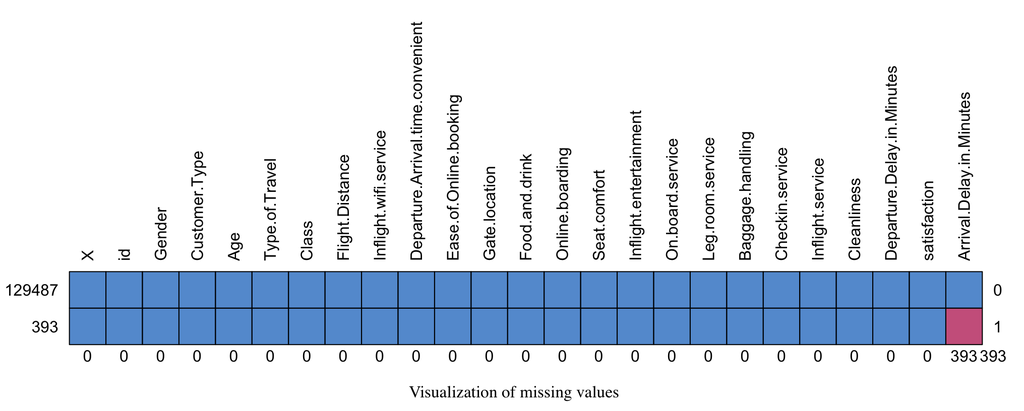

```r
#md.pattern(all, rotate.names = TRUE)
knitr::include_graphics("/Users/mac/Desktop/STAT5003/Project/FinalReport/Missings.png")
```

There is only one feature in the total collection named Arrival.Delay.in.Minutes with 393 missing values.

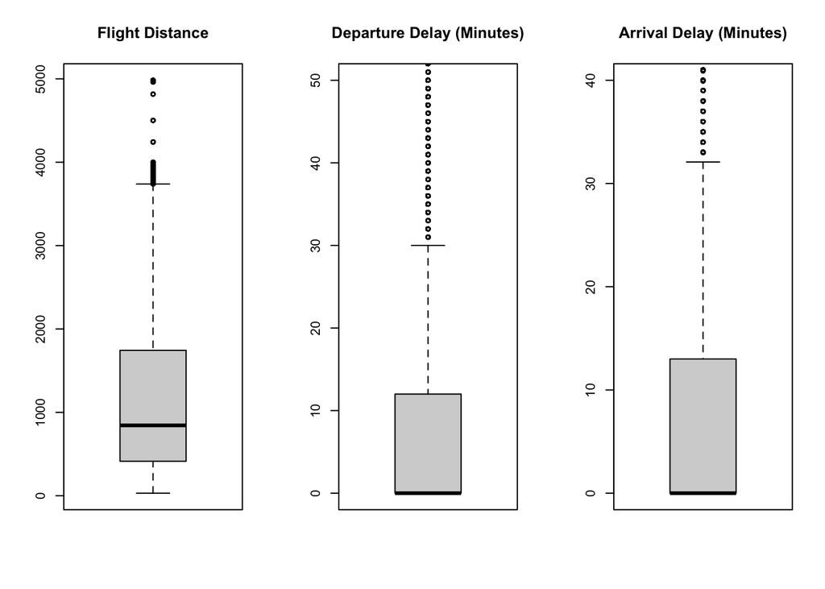

```r
par(mfrow = c(1,3))

y<-factor(all$satisfaction)

boxplot(all$Flight.Distance,main = "Flight Distance")
boxplot(all$Departure.Delay.in.Minutes,main = "Departure Delay (Minutes)",ylim=c(0,50))
boxplot(all$Arrival.Delay.in.Minutes,main = "Arrival Delay (Minutes)",ylim=c(0,40))
```

### 3.2 Perform and describe any appropriate data cleaning

Missing values exist in Arrival.Delay.in.Minutes, it shows a strong positive correlation with the feature of Departure.Delay.in.Minutes that can be seen from the correlation plot at 0.96; therefore, the missing values in Arrival.Delay.in.Minutes can be filled in by predicted values from adopting simple linear regression based on Departure.Delay.in.Minutes. We filtered out outliers over 1,500 in Departure.Delay.in.Minutes and the Arrival.Delay.in.Minutes by subsetting.

### 3.3 Highly correlated features

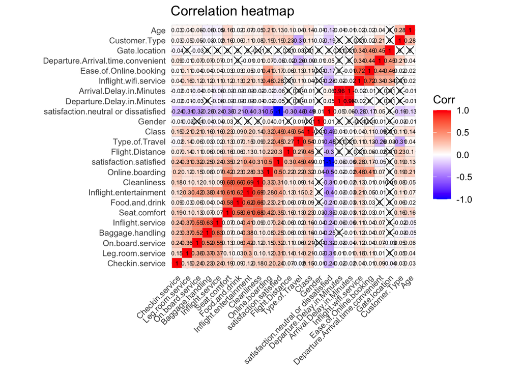

```r
cor_data = no_outliers_all[-1][-1]
cor_data$satisfaction = class.ind(cor_data$satisfaction)
library(corrplot)
corr1 <- round(cor(cor_data), 3)
library(ggcorrplot)
pcor_data <- cor_pmat(cor_data)
ggcorrplot(corr1,
           hc.order = TRUE,
           colors = c("Blue","white","red"),
           lab = TRUE,lab_size = 2,    #cor text size
           tl.cex = 8,             #axis title size
           p.mat = pcor_data,         # p value
           sig.level = 0.01,        #significant value
           pch = 4,
           pch.cex = 3,
           title ='Correlation heatmap')
```

The graph above illustrates the correlation coefficient between the different features with a significant p-value of 0.01. In this graph, values above 0.5 are considered to be highly correlated. Firstly we can observe that the feature ‘Arrival.Delay.in.Minutes’ highly positively correlates with the feature ‘Departure.Delay.in.Minutes’ with a value of 0.96. In addition, ‘Inflight.wifi.service’ is highly positively correlated with ’Ease.of.online.booking‘ with a value of 0.72. There was also a high correlation between four features, they are ‘Cleanliness’, ‘Inflight.entertainment’, ‘Food.and.drink’ and ‘Seat.comfort’. There is another highly correlated relationship in this graph involving ‘Baggage.handling’, ‘On.board.service’ and ‘Inflight.service’.

### 3.4 Histograms and density estimations

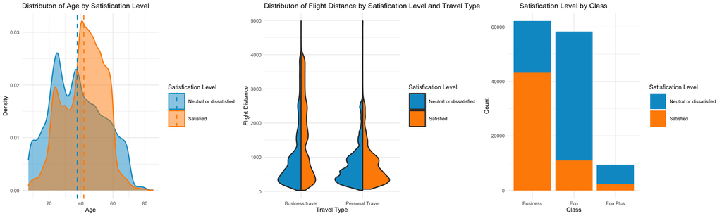

```r
#age
means <- df.tbl %>%
  group_by(satisfaction) %>%
  summarise(mean = mean(Age))

plot1 <- ggplot(df.tbl,aes(x=Age,color=factor(satisfaction),fill=factor(satisfaction))) +
  scale_color_manual(values = c("deepskyblue3","darkorange"),labels=c("Neutral or dissatisfied","Satisfied")) +
  scale_fill_manual(values = c("deepskyblue3","darkorange"),labels=c("Neutral or dissatisfied","Satisfied"))+
  geom_density(alpha=0.5) +
  geom_vline(data = means, aes(xintercept = mean, color=factor(satisfaction)),linetype="dashed") +
  labs(title = "Distributon of Age by Satisfication Level",
       x = "Age",
       y = "Density",
       fill="Satisfication Level",
       color="Satisfication Level")+
 theme_minimal(base_size = 6)



# flight distance & travel type
library(ggunchained)

plot3 <- ggplot(df.tbl,aes(x=Type.of.Travel,y=Flight.Distance,fill=factor(satisfaction)))+
  geom_split_violin()+
  scale_fill_manual(values = c("deepskyblue3","darkorange"),labels=c("Neutral or dissatisfied","Satisfied"))+
  labs(title = "Distributon of Flight Distance by Satisfication Level and Travel Type",
       x = "Travel Type",
       y = "Flight Distance",
       fill="Satisfication Level")+
 theme_minimal(base_size = 6)

# class
plot4 <- ggplot(df.tbl, aes(Class, fill = factor(satisfaction))) +
  geom_bar() +
  labs(title = "      Satisfication Level by Class",
       x = "Class",
       y = "Count",
       fill="Satisfication Level") +
  scale_fill_manual(values = c("deepskyblue3","darkorange"),labels=c("Neutral or dissatisfied","Satisfied"))+
  theme_minimal(base_size = 6)
library(gridExtra)
grid.arrange(plot1,plot3,plot4, ncol=3, nrow = 1)
```

Age: When other features are not considered, older people ageing between 40 to 60 tend to be satisfied whereas younger people who are 20 to 40 years tend to feel neutral or dissatisfied with the flight.

Flight distance & Travel type: Business travels usually have longer flight distance compared to personal travel. Business travellers seem to be more satisfied when they travel in a longer distance. Other than that, it does not seem to affect much in the satisfaction level.

## 4. Feature selection

Feature engineering includes addressing missing values, removing outliers and reduce dimensions to improve the performance of classifiers.

**Checking any imbalance issue in the dataset:** The dataset is relatively balanced with the “neutral or dissatisfied” class being 13% higher than the “satisfied” class. Rather than balancing our dataset to 50:50, we decided to adding Recall, Precision and F-1 score evaluation metrics on top of the accuracy metric, so that the classifiers’ performance exploring on this relatively balanced data can be better evaluated.

**Encoding categorical variables:** We encode categorical variables differently for feature in ordinal nature and in nominal nature. For ordinal nature feature, such as Class, we encode it, where 0 represents Eco class, 1 represents Eco plus class and 2 represents Business class. while other categorical variables were encoded by dummy variables with 0 and 1.

**Dimensionality reduction:**

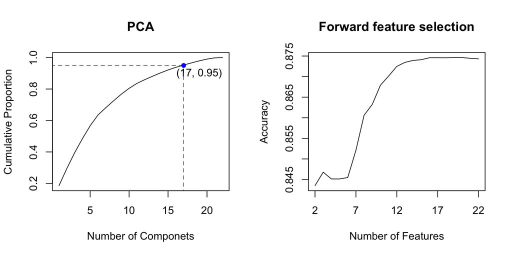

```r
class <- df[["satisfaction"]]
num.dat <- df %>% select(!satisfaction)
pca_res <- prcomp(num.dat,scale=TRUE,center = TRUE)
cproportion <- cumsum(pca_res$sdev^2 / sum(pca_res$sdev^2))
# Forward Stepwise selection
set.seed(31)
inTrain <- createDataPartition(df$satisfaction, p = 0.5)[[1]]
train <- df[inTrain,]
test  <- df[-inTrain,]
cls.train <- df$satisfaction[inTrain]
cls.test <- df$satisfaction[-inTrain]

selectFeature <- function(train, test, cls.train, cls.test, features) {
  current.best.accuracy <- -Inf
  selected.i <- NULL
  for (i in seq(ncol(train))) {
    current.f <- colnames(train)[i]
    if (!current.f %in% c(features,"satisfaction")) {
      model <- train(satisfaction ~ .,
                     data = train[,c(features,current.f,"satisfaction")],
                     method ="glm", family = "binomial")
      Pred <- predict(model,newdata = test[,c(features,current.f,"satisfaction")])
      test.acc <- sum(Pred == cls.test) / length(cls.test)

      if (test.acc > current.best.accuracy) {
        current.best.accuracy <- test.acc
        selected.i <- colnames(train)[i]
      }
    }
  }
  return(c(selected.i,current.best.accuracy))
}

features <- NULL
accuracy <- NULL
# select the 1 to 17 best features using knn as a wrapper classifier
for (j in 1:22) {
  res <- selectFeature(train, test, cls.train, cls.test, features)
  selected.i<-res[1]
  current.best.accuracy<-res[2]
  print(c(selected.i,current.best.accuracy))
  features <- c(features, selected.i)
  accuracy <- c(accuracy,current.best.accuracy)
}

FeatureSelection <- data.frame(Features=features,
                               Accuracy=accuracy)
write.csv(FeatureSelection,"FeatureSelection.csv")
FeatureSelection <-read.csv("FeatureSelection.csv")
Acc<- FeatureSelection[['Accuracy']]
write.csv(FeatureSelection,"FeatureSelection.csv")
```

There is no perfect multicollinearity issue as no coefficient exactly equal to 1. So we did not remove any feature based on the correlation. We apply the principal component analysis (PCA) to reduce the dimensionality. From the elbow plot we can discover that 17 features capture 95% principal component. However, there are not dominant features in the principle components, which doesn’t show a good separation between two clusters and isn’t interpretable enough. So we perform forward stepwise feature selection to select 17 best features using logistic regression as a wrapper classifier. From the accuracy graph, we can see that when number of features is over 17, the accuracy doesn’t seem to improve much. And we also need to consider that we may lose information that can be used by some ensemble methods if we drop some features, so we finally select 17 features.

## 5. Algorithms

### 5.1 Logistic regression

```r
set.seed(5003)
inTrain <- createDataPartition(df$satisfaction, p = 0.7)[[1]]
train <- df[inTrain,]
test  <- df[-inTrain,]
cls.train <- df$satisfaction[inTrain]
cls.test <- df$satisfaction[-inTrain]

# Selected features model
tuneGrid=data.frame(alpha=rep(c(0,1),3),lambda=c(0,0,0.1,0.1,1,1)) # Ridge or Lasso penalty, lambda=0 means no penalty
logistic.model <- train(satisfaction ~ .,
               data = train[,c(selected,"satisfaction")],
               method ="glmnet", family = "binomial",
               trControl = trainControl(method = "repeatedcv",
                                        number=10,
                                        repeats = 3),
               tuneGrid=tuneGrid) # Repeat 10-folds CrossValidation 3 times
logistic.model
logistic.model$bestTune
logistic.pred <- predict(logistic.model,newdata = test[,c(selected,"satisfaction")])

# calculate the runing time
best.logGrid = expand.grid(alpha = 1
                     ,lambda = 0
)
log.start<-Sys.time()
best.log1 = train(satisfaction~., data = train[,c(selected,"satisfaction")], method="glmnet", trControl=train_control,verbose=FALSE,tuneGrid = best.logGrid,metric = "Accuracy")
log.end<-Sys.time()
log.runningtime<-log.end-log.start
cat(log.runningtime)

logistic.model$bestTune
# draw the plot of the hyperparameter tuning
log.mod.results<-logistic.model$results

logistic.model$bestTune

plot(c(1,2,3,4,5,6),log.mod.results$Accuracy,main="hyperparameter tuning of logistic regression",ylab="accuracy",xlab="combination",type="b",ylim=c(0.5,1),xlim=c(0.5,6.5))
text(c(1,2,3,4,5,6),log.mod.results$Accuracy,round(log.mod.results$Accuracy,3),cex=1,pos=3) #it is used to test the point in the plot
```

[output not shown]

|  | alpha | lambda |
| --- | --- | --- |
| 4 | 1 | 0 |

Logistic regression is a technique used in machine learning to assess the likelihood of something by finding solutions to problems with binary (0 or 1) answers. First, because our project is a binary problem, the only possible classifications are “satisfied,” and “neutral or satisfied.” Second, the Logistic Regression model is simple to comprehend, and it offers a great deal of interpretability. The relative weights of the various features provide insight into the influence those features have on the overall outcome. Logistic Regression is a model that is considered to be reasonably straightforward and fundamental, which is why we have chosen to utilize it as our baseline model. Finally, there are many available numerical optimisation methods that can be used to determine the ideal answer, and the training speed is rapid.

When developing the model, the initial step was to determine which combination of the hyperparameters alpha and lambda produced the best results. We tried a variety of different combinations with alpha = 0 and 1 and lambda = 0, 0.1 and 1, and in the end, we came to the conclusion that the accuracy of the model of hyperparameter combination is highest when alpha = 1 and lambda = 0. This also indicates that there is no penalty in the Logistic Regression model. The fitted model makes use of the glm() function, with the family parameter set to “binomial.” This indicates that the connection function is “logit,” which is shorthand for logistic regression. The resampling technique for repeatedcv is defined by trControl as part of the list of parameters for the function that will be executed; number = 10 and repeats = 3 signifies that the number of iterations (CrossValidation) should be repeated three times, followed by 10 folds of resampling. Our logistic regression model produced an accuracy value of 0.8738 and a Kappa value of 0.7418 as its final result.

### 5.2 GBM: Gradient Boosting

```r
# 10 fold cross validation with 3 repeats
train_control <- caret::trainControl(method = "repeatedcv", number = 10, repeats = 3)

library(gbm)
gbmGrid = expand.grid(
   n.trees = c(100,500,1000) # iterations
  ,interaction.depth = c(1,2,6,9)
  ,shrinkage = 0.1 # learning rate
  # This default uses very slow learn rates for small data sets and uses 0.1 for all data sets with more than 10,000 records.
  ,n.minobsinnode = c(3,5,10)
  )

set.seed(5003)
fit_gbm = train(satisfaction~., data = train[,c(selected,"satisfaction")], method="gbm", trControl=train_control,tuneGrid = gbmGrid,metric = "Accuracy", verbose=FALSE)

fit_gbm

library(gbm)
best_gbmGrid = expand.grid(
   n.trees = 1000
  ,interaction.depth = 9
  ,shrinkage = 0.1
  ,n.minobsinnode = 5
  )
gbm.start<-Sys.time()
best_gbm = train(satisfaction~., data = train[,c(selected,"satisfaction")], method="gbm", trControl=train_control,tuneGrid = best_gbmGrid,metric = "Accuracy", verbose=FALSE)
gbm.end<-Sys.time()
gbm.runningtime<-gbm.end-gbm.start
cat(gbm.runningtime)

gbm.pred <- predict(best_gbm,newdata = test[,c(selected,"satisfaction")])
Mat_gbm <- caret::confusionMatrix(data=gbm.pred,reference=cls.test,positive="satisfied")
Mat_gbm

fit_gbm$bestTune
```

|  | n.trees | interaction.depth | shrinkage | n.minobsinnode |
| --- | --- | --- | --- | --- |
| 33 | 1000 | 9 | 0.1 | 5 |

Gradient Boosting is a type of ensemble machine learning algorithm that can be used for classification predictive modelling problems. Here, we chose this model because it is effective and often a key algorithm utilized to win machine learning competitions (like Kaggle) on tabular data. While Basic Gradient Boosting can overfit a training set quickly, Stochastic Gradient Boosting can benefit from a regularization that introduces randomness and reduces the correlation between the trees. Thus, the issue of overfitting can be solved. In this algorithm, a base learner should be fitted on a randomly selected (without replacement) subsample of the training data at each iteration. With this minor modification, the performance of gradient boosting can be improved a lot.

To improve the accuracy of the algorithm when specifically working for our dataset, we need to tune hyperparameters. There are only four hyperparameters that can be configured in this algorithm: “n.trees”, “interaction.depth”, “shrinkage”, and “n.minobsinnode”. The parameter “n.trees” refers to the number of trees or iterations in the model. Although larger numbers of trees can help to reduce the training error, it would lead to overfitting if set too high. The parameter “interaction.depth” refers to the number of leaves or the maximum depth of each tree. The order of approximation can be restricted by setting up the tree depth. According to previous work, the default six-node tree appears to do an excellent job. The parameter “shrinkage” refers to the learning rate of the model. In GBM, shrinkage is used to reduce the impact of each additional fitted tree. When lambda is as small as possible, the model can be improved by taking many small steps so that the negative impact of any boosting iteration can be corrected in subsequent steps. The parameter “n.minobsinnode” refers to the minimum number of samples in a tree’s terminal nodes. This number should be set lower if the training set is small.

Since our dataset has more than 100,000 records, we set the learn rate to 0.1 first. Then, by using the method of 10 fold cross validation with 3 repeats, we tested the number of iterations with 100, 500, 1000, the maximum depth of each tree with 1, 2, 6, 9, and the minimum number of observations in the tree’s terminal nodes with 3, 5, 10. The model performs best when “n.trees” equals 1000, “interaction.depth” equals 9, and “n.minobsinnode” equals 5. Finally, we got the highest accuracy of 95.59% and the kappa statistic of 91.73%.

### 5.3 CatBoost

```r
# Mac
# devtools::install_url('https://github.com/catboost/catboost/releases/download/v1.1/catboost-R-Darwin-1.1.tgz', INSTALL_opts = c("--no-multiarch", "--no-test-load"))
# Windows
# devtools::install_url('https://github.com/catboost/catboost/releases/download/v0.7.2/catboost-R-Windows-0.7.2.tgz', args = c("--no-multiarch"))
set.seed(5003)
library(catboost)

catGrid <- expand.grid(depth = c(1,10),
                       learning_rate = c(0.01,0.1),
                       iterations = c(50,200),
                       l2_leaf_reg = c(1e-3,3),
                       rsm = 1,
                       border_count = c(64,128))

fit_cat = train(x = train[,selected], y = train[,c(selected,"satisfaction")]$satisfaction, method = catboost.caret,logging_level = 'Verbose', preProc = NULL,tuneGrid = catGrid, trControl = train_control)
fit_cat
library(catboost)
set.seed(5003)
best_catGrid = expand.grid(
   depth = 10,
   learning_rate = 0.1,
   iterations = 200,
   l2_leaf_reg = 3,
   rsm = 1,
   border_count = 64
  )
catboost.start<-Sys.time()  #calculate the running time
best_cat = train(x = train[,selected], y = train[,c(selected,"satisfaction")]$satisfaction, method = catboost.caret,logging_level = 'Verbose', preProc = NULL,tuneGrid = best_catGrid, trControl = train_control)
catboost.end<-Sys.time()
catboost.runningtime<-catboost.end-catboost.start
cat(catboost.runningtime)


cat.pred <- predict(best_cat,newdata = test[,c(selected,"satisfaction")])
Mat_cat <- caret::confusionMatrix(data=cat.pred,reference=cls.test,positive="satisfied")
Mat_cat

fit_cat$bestTune
```

|  | depth | learning_rate | iterations | l2_leaf_reg | rsm | border_count |
| --- | --- | --- | --- | --- | --- | --- |
| 30 | 10 | 0.1 | 200 | 3 | 1 | 64 |

Category Gradient Boosting (Catboost) is another variation of the gradient boosting algorithm with an efficient implementation. It also has some advantages, such as improved computational speed and support for categorical input variables. The trees in CatBoost are balanced, which means that the splitting condition must be consistent across all nodes at the same depth. This symmetric tree architecture can help prevent overfitting and accelerate evaluation. The splitting condition in CatBoost is determined by using a greedy method to choose the split that results in the smallest penalty from a list of possible feature-split pairs assigned to the leaf as the split. Catboost is an ordered boosting method that increases robustness to unseen data.

We focus on fine tuning six model parameters: “depth”, “learning_rate”, “iterations”, “12_leaf_reg”, “rsm”, and “border_count” to improve accuracy, speed, and prevent overfitting. The parameter “depth” refers to the depth of a tree, which controls the complexity of the model. The parameter “learning_rate” refers to the learning rate for reducing gradient steps. This parameter is used to prevent overfitting. The parameter “iterations” refers to the number of trees. Tuning this parameter can improve the computational speed. The parameter “12_leaf_reg” is a regularization, which also benefits on controlling overfitting. The parameter “rsm” refers to a random subspace method, which is a fraction of the number of features used in a split selection. This is a parameter that works for faster speed. The parameter “border_count” refers to the number of splits for numerical features. This is also a parameter that slightly impacts the speed of training on the CPU.

In our experiment, we configured “depth” as 1 and 10, “learning_rate” as 0.01 and 0.1, “iterations” as 50 and 200, “12_leaf_reg” as le-3 and 3, “rsm” as 1, and “border_count” as 64 and 128. Then, we use 10 fold cross validation with 3 repeats again to find out the combination of parameters that results in the best performance. The highest accuracy is 96.23% and the highest kappa statistic is 92.3%, with “depth” equals 10, “learning_rate” equals 0.1, “iterations” equals 200, “12_leaf_reg” equals 3, “rsm” equals 1, and “border_count” equals 64.

### 5.4 Naive Bayes

```r
library(klaR)
set.seed(5003)
nbGrid = expand.grid(fL = c(0,0.1,1,5) #Laplace Correction
                     ,usekernel = c(TRUE,FALSE) #Distribution Type
                     ,adjust=c(0.1,1,5) #Bandwidth Adjustment
)

fit_nb = train(satisfaction~., data = train[,c(selected,"satisfaction")], method="nb", trControl=train_control,tuneGrid = nbGrid,metric = "Accuracy",verbose=FALSE)
fit_nb

library(klaR)
set.seed(5003)
best.nbGrid = expand.grid(fL = 0 #Laplace Correction
                     ,usekernel = c(TRUE) #Distribution Type
                     ,adjust=1 #Bandwidth Adjustment
)

nb.start<-Sys.time()
best.nb1 = train(satisfaction~., data = train[,c(selected,"satisfaction")], method="nb", trControl=train_control,verbose=FALSE,tuneGrid = best.nbGrid,metric = "Accuracy")
nb.end<-Sys.time()
nb.runningtime<-nb.end-nb.start
cat(nb.runningtime)

nb.pred <- predict(best.nb1,newdata = test[,c(selected,"satisfaction")])
Mat_nb <- caret::confusionMatrix(data=nb.pred,reference=cls.test,positive="satisfied")
Mat_nb

nb.mod.results<-fit_nb$results
plot(c(seq(from=1,to=24,by=1)),nb.mod.results$Accuracy,main="hyperparameter tuning of naive bayes",ylab="accuracy",xlab="combination",type="b",ylim=c(0.86,0.90))
text(c(seq(from=1,to=24,by=1)),nb.mod.results$Accuracy,round(nb.mod.results$Accuracy,3),cex=1,pos=3) #it is used to test the point in the plot
```

[output not shown]

|  | fL | usekernel | adjust |
| --- | --- | --- | --- |
| 5 | 0 | TRUE | 1 |

Naïve Bayes is a classical supervised machine learning algorithm that is used to do classification work. It is based on the Bayes Theorem as well as the idea that each variable in the model is independent of the others. However, the predictor variables cannot be absolutely independent of each other in the real world. Since Naïve Bayes considers there are no correlations between the predictor variables, it is called ‘Naïve’. This logic might have some negative impact on the accuracy of the machine learning model. Although it is often outperformed by other classifiers, Naïve Bayes can work fast and scale well, and has good performance on many classification problems.

Here, we use the klaR package to build a Naïve Bayes classifier. This model has three hyperparameters to tune: “fL”, “usekernel”, and “adjust”. The parameter “fL” refers to the factor of Laplace correction, which is used to incorporate the Laplace smoother. The bigger the Laplace smoothing value, the more the models are made the same. The parameter “usekernel” refers to a choice of using the kernel density estimate for continuous variables or a gaussian density estimate. When using the klaR engine, the “usekernel” is set to TRUE by default. The parameter “adjust” helps to control the bandwidth of the kernel density. The larger value of the engine argument “adjust” means a more flexible density estimate.

Again, we applied the 10 fold cross validation with 3 repeats to select the best Naïve Bayes model parameters, with “fL” set to 0, 0.1, 1, 5, “usekernel” set to TRUE, FALSE, and “adjust” set to 0.1, 1, 5. We found that the highest accuracy always occurs when “userkernel” is set to TRUE and “adjust” equals 1, no matter how “fL” is configured. However, this zero-probability event does not mean an impossible event. Thus, the final values used for the model are: “usekernel” equals TRUE, and “adjust” equals 1. The accuracy of the best model reaches 89.33%, with a kappa statistic of 78.4%.

### 5.5 Random Forest

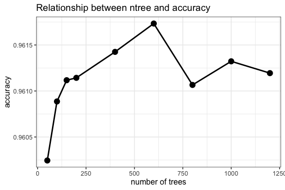

```r
library(randomForest)
library(ggplot2)
set.seed(5003)
rf.acc.test<-c()
for (i in c(seq(from=50,to=150,by=50),seq(from=200,to=1200,by=200))){
  randomforest.model<-randomForest(satisfaction~.,data=train[,c(selected,"satisfaction")],ntree=i)
  randomforest.pred<-predict(randomforest.model,newdata=test[,c(selected,"satisfaction")])
  test.acc<-sum(randomforest.pred==cls.test)/length(cls.test)
  rf.acc.test<-c(rf.acc.test,test.acc)
}

rf.acc.test1<-c(rf.acc.test)
ntree1<-c(seq(from=50,to=150,by=50),seq(from=200,to=1200,by=200))
randomforest.df<-data.frame(ntree1,rf.acc.test1)

library(ggplot2)
ggplot(randomforest.df,aes(x=ntree1,y=rf.acc.test1))+geom_point()+geom_line()+ggtitle("Relationship between ntree and accuracy")+xlab("number of trees")+ylab("accuracy")+theme_bw()
```

A random forest, in its most basic form, is a forest that has been constructed in an arbitrary fashion using numerous different decision trees, and none of which are connected to one another in any manner. When a new sample is input after a forest has been obtained, each decision tree in the forest will make a determination, classify the category (for the purpose of a classification algorithm), and then compare which category is judged to be the most prevalent in order to determine which category the sample belongs to. For more precise, Random forests are a classification approach that are utilized as part of an ensemble. The development of decision trees based on the provided training data and the comparison of these to the test data are both included in the technique. When solving a classification problem, statisticians turn to random forests to determine the relative relevance of the various factors[2]. In this particular project, random forest is a fantastic choice for us since it can manage the enormous quantity of data to classify them and minimize the dimensionality without us having to conduct any feature selection.

## 6. Evaluation

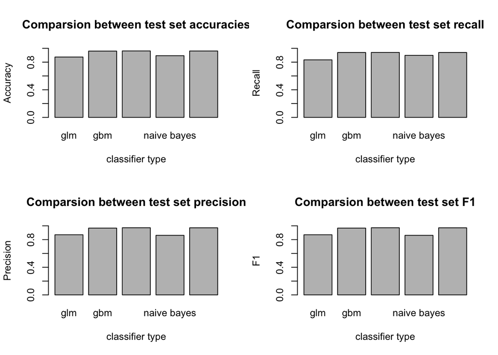

```r
# logistic regression model confusion matrix and statistics
Mat_log <- caret::confusionMatrix(data=logistic.pred,reference=cls.test,positive="satisfied")
Mat_log

# gbm model confusion matrix and statistics
Mat_gbm <- caret::confusionMatrix(data=gbm.pred,reference=cls.test,positive="satisfied")
Mat_gbm

# catboost model confusion matrix and statistics
Mat_cat <- caret::confusionMatrix(data=cat.pred,reference=cls.test,positive="satisfied")
Mat_cat

# naive bayes model confusion matrix and statistics
Mat_nb <- caret::confusionMatrix(data=nb.pred,reference=cls.test,positive="satisfied")
Mat_nb

# random forest model confusion matrix and statistics
Mat_rf<-caret::confusionMatrix(data=randomforest.pred2,reference=test$satisfaction,positive="satisfied")
Mat_rf

# compare accuracy
comparison_acc<-c(Mat_log$overall["Accuracy"],Mat_gbm$overall["Accuracy"],Mat_cat$overall["Accuracy"],Mat_nb$overall["Accuracy"],Mat_rf$overall["Accuracy"])%>%unlist()%>%as.vector()

barplot(comparison_acc,ylim=c(0,1),names.arg=c("glm","gbm","catboost","naive bayes","random forest"),xlab="classifier type",ylab="Accuracy",main ="Comparsion between test set accuracies",axes=TRUE)

# compare recall
comparison_recall<-c(Mat_log$byClass["Recall"],Mat_gbm$byClass["Recall"],Mat_cat$byClass["Recall"],Mat_nb$byClass["Recall"],Mat_rf$byClass["Recall"])%>%unlist()%>%as.vector()
barplot(comparison_recall,ylim=c(0,1),names.arg=c("glm","gbm","catboost","naive bayes","random forest"),xlab="classifier type",ylab="Recall",main ="Comparsion between test set recall",axes=TRUE)

# compare precision
comparison_precision<-c(Mat_log$byClass["Precision"],Mat_gbm$byClass["Precision"],Mat_cat$byClass["Precision"],Mat_nb$byClass["Precision"],Mat_rf$byClass["Precision"])%>%unlist()%>%as.vector()
barplot(comparison_precision,ylim=c(0,1),names.arg=c("glm","gbm","catboost","naive bayes","random forest"),xlab="classifier type",ylab="Precision",main ="Comparsion between test set precision",axes=TRUE)

# compare F1
comparison_F1<-c(Mat_log$byClass["F1"],Mat_gbm$byClass["F1"],Mat_cat$byClass["F1"],Mat_nb$byClass["F1"],Mat_rf$byClass["F1"])%>%unlist()%>%as.vector()
barplot(comparison_precision,ylim=c(0,1),names.arg=c("glm","gbm","catboost","naive bayes","random forest"),xlab="classifier type",ylab="F1",main ="Comparsion between test set F1",axes=TRUE)
```

The plot on the top left compares the classification accuracy rates on the test dataset. Apparently, the ensemble methods, including gradient boosting, catboost and random forest, outperforms that of the others. Catboost method gained the highest than the others at 96.23% whereas logistic regression had the lowest accuracy rate at 87.38%.

Although our dataset is relatively balanced, the negative class is still 13% higher than the positive satisfied class. So we also used recall, precision and f1 – score metrics. Ensemble methods are again much higher than logistic regression and Naïve Bayes in each metric. The distribution of all metrics are similar, indicating our more or less imbalanced dataset indeed does not affect the result.

```r
library(pROC)

# logistic regression
logistic.roc<-pROC::roc(test[,c(selected,"satisfaction")]$satisfaction,as.numeric(logistic.pred))
logistic.auc<-round(auc(test[,c(selected,"satisfaction")]$satisfaction,as.numeric(logistic.pred)),4)
pROC::ggroc(logistic.roc,colour='green',size=2)+ggtitle(paste0('ROC curve of logistic regression model','(AUC=',logistic.auc,')'))+theme_bw()+geom_segment(aes(x=1,xend=0,y=0,yend=1),color="grey",linetype="dashed")

# gbm
gbm.roc<-pROC::roc(test[,c(selected,"satisfaction")]$satisfaction,as.numeric(gbm.pred))
gbm.auc<-round(auc(test[,c(selected,"satisfaction")]$satisfaction,as.numeric(gbm.pred)),4)
pROC::ggroc(gbm.roc,colour='purple',size=2)+ggtitle(paste0('ROC curve of gbm model','(AUC=',gbm.auc,')'))+theme_bw()+geom_segment(aes(x=1,xend=0,y=0,yend=1),color="grey",linetype="dashed")

# catboost
cat.roc<-pROC::roc(test[,c(selected,"satisfaction")]$satisfaction,as.numeric(cat.pred))
cat.auc<-round(auc(test[,c(selected,"satisfaction")]$satisfaction,as.numeric(cat.pred)),4)
pROC::ggroc(cat.roc,colour='red',size=2)+ggtitle(paste0('ROC curve of catboost model','(AUC=',cat.auc,')'))+theme_bw()+geom_segment(aes(x=1,xend=0,y=0,yend=1),color="grey",linetype="dashed")

# naive bayes
nb.roc<-pROC::roc(test[,c(selected,"satisfaction")]$satisfaction,as.numeric(nb.pred))
nb.auc<-round(auc(test[,c(selected,"satisfaction")]$satisfaction,as.numeric(nb.pred)),4)
pROC::ggroc(nb.roc,colour='blue',size=2)+ggtitle(paste0('ROC curve of nb model','(AUC=',nb.auc,')'))+theme_bw()+geom_segment(aes(x=1,xend=0,y=0,yend=1),color="grey",linetype="dashed")

# ROC of randamforest
randomforest.roc<-pROC::roc(test[,c(selected,"satisfaction")]$satisfaction,as.numeric(randomforest.pred2))  #randomforest.pred2 should be numeric
randomforest.auc<-round(auc(test[,c(selected,"satisfaction")]$satisfaction,as.numeric(randomforest.pred2)),4)
pROC::ggroc(randomforest.roc,colour='blue',size=2)+ggtitle(paste0('ROC curve of random forest model','(AUC=',randomforest.auc,')'))+theme_bw()+geom_segment(aes(x=1,xend=0,y=0,yend=1),color="grey",linetype="dashed")

pROC::ggroc(list(randomforest=randomforest.roc,logistic_regression=logistic.roc,naive_bayes=nb.roc,catboost=cat.roc,gbm=gbm.roc))+ggtitle("Comparsion of ROC curve")+theme_bw()+geom_segment(aes(x=1,xend=0,y=0,yend=1),color="grey",linetype="dashed")
```

[output not shown]

Comparision of ROC curve:

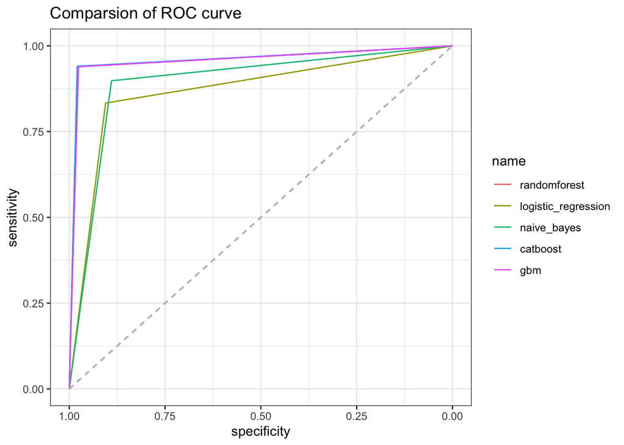

We have also plotted the Receiver Operating Characteristics curve. The higher the area under the curve, shorting for AUC, the better the model is capable of distinguishing between classes. Again, ensemble methods resulted in much higher AUCs at around 0.96 than that of logistic regression at around 0.8691 and naïve_bayes at 0.8939. Overall, ensemble methods outperform logistic regression and naïve bayes. This may be because they combine multiple models and boost better overall accuracy compared to a single algorithm.

```r
Models = c("Logistic Regression","Naive Bayes","Random Forest","Gradient Boosting","CatBoost")
Time = c("2 min","7 min","3 min","48 min","12 min")
table1 = data.frame(Models, Time)
table1
```

| Models | Time |
| --- | --- |
| Logistic Regression | 2 min |
| Naive Bayes | 7 min |
| Random Forest | 3 min |
| Gradient Boosting | 48 min |
| CatBoost | 12 min |

The running time on the test data for Gradient Boosting is the slowest at around 48 minutes, but for the other two ensemble methods, the running time is much better, with CatBoost at 12 minutes and Random Forest at only 3 minutes. Naïve Bayes and logistic regression also performed well in running time.

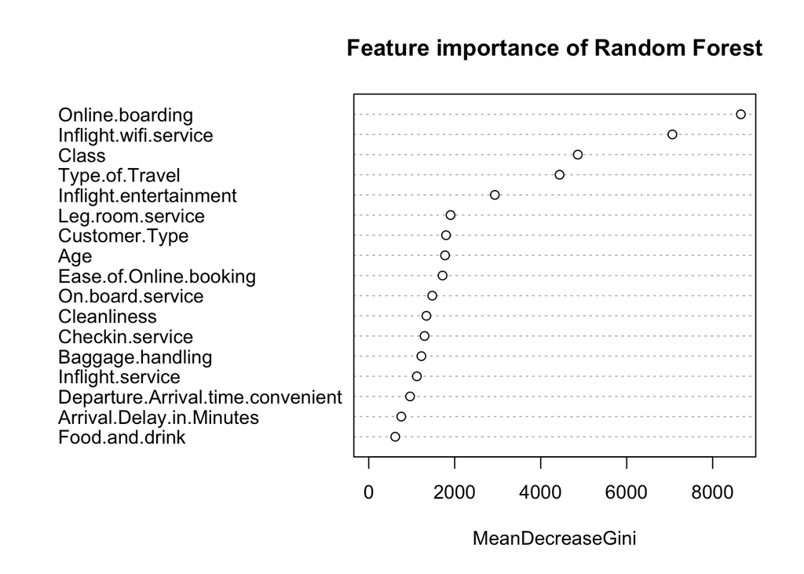

```r
library(randomForest)
library(ggplot2)
set.seed(5003)

rf.start<-Sys.time()
randomforest.model2<-randomForest(satisfaction~.,data=train[,c(selected,"satisfaction")],ntree=600)
rf.end<-Sys.time()
rf.runningtime<-rf.end-rf.start
cat(rf.runningtime)

randomforest.pred2<-predict(randomforest.model2,newdata=test[,c(selected,"satisfaction")])

# use the plot to show predictor variables rank which helps interpretation.
library(randomForest)
varImpPlot(randomforest.model2)
```

## 7. Conclusion

Limitations: In the feature selection section, less features can be selected to compare with 17 features resulting from PCA at 95%. Besides, due to the constraint of computational complexity and large data size, classifiers such as SVM can not be trained; besides, some hyper-parameters are hardly to be tuned.

Future works: In future works, firstly, we can try other feature engineering methods and train and test our dataset for less features and compare whether there is a considerable decrease in the accuracy rate. Besides, other hyper – parameters are also worth to be tuned when we have a better computer hardware environment.

## 8. Reference

[1] Airline Passenger Satisfaction. [Online]. Available: https://www.kaggle.com/datasets/teejmahal20/airline-passenger-satisfaction

[2] R, P.T. (2015) “A comparative study on decision tree and Random Forest using r tool,” IJARCCE, pp. 196–199. Available at: https://doi.org/10.17148/ijarcce.2015.4142.

## 9. Contribution

All members contribute equally on all aspects of this project.